# Sparse Clustering Algorithm

Paul Harmon

9/4/2019

## Sparcl packages

Witten includes several of the important functions called by the sparse clustering package in her Github page (link: https://github.com/cran/sparcl).

## Datasets:

I’m using a couple of standard datasets that I like to utilize:

- NBA pointguards
- Colorado housing prices
- NFL QB stats

```r
#reads in datasets
house <- read_csv("data/house_train.csv")
nba <- read_csv("data/na.csv")
qb <- read_csv("data/QBStats_all.csv")
```

Dimensions of the data are shown below:

```r
dim(house)
```

```
## [1] 1460   81
```

```r
dim(nba)
```

```
## [1] 52 23
```

```r
dim(qb)
```

```
## [1] 13188    14
```

## Sparcl Algorithm

The sparse clustering algorithm can be defined for hierarchical clustering as follows:

- Initial clustering solution
- Update the weights w2 (set usually as $\frac{1}{\sqrt{p}}$)
- Update u, w until convergence
- Generate the new dissimilarity matrix U (that is now sparse) and perform hierarchical clustering on it

Based on the above methodology, the actual calculation of the sparse clustering is separate from the hierarchical clustering that is performed in the final step. A different clustering method, such as monothetic clustering, could be easily used in the same framework.

I could easily read in the ‘sparcl’ package and apply the function; however, instead I’m using Witten’s code piece by piece to get a better sense for how the algorithm works and what is necessary to make changes.

## Sparse Clustering of NBA Data

We can try assessing the NBA data with sparcl with several different choices for tuning parameters. Initially, we run the model with the default settings and outline some of the relevant outputs:

- Weight Vector (p)
- Dissimilarity metrix U

```r
library(sparcl)
nba_mat <- as.matrix(nba[,-c(1:3)]) #needs things taken as a matrix
nba_clust <- nba_mat %>% HierarchicalSparseCluster()
```

```
## 1234567
```

```r
#prints distance matrix
nba_clust$u
```

```
##               1            2           3            4            5
## 1  0.0000000000 0.0005564159 0.008540129 0.0024013330 0.0023913080
## 2  0.0005564159 0.0000000000 0.008376556 0.0019430425 0.0012500574
## 3  0.0085401291 0.0083765563 0.000000000 0.0129091688 0.0089109285
## 4  0.0024013330 0.0019430425 0.012909169 0.0000000000 0.0008900912
## 5  0.0023913080 0.0012500574 0.008910929 0.0008900912 0.0000000000
## 6  0.0008806186 0.0010132333 0.012330629 0.0030319460 0.0036999368
## 7  0.0017520991 0.0008376050 0.004686546 0.0032772544 0.0012996279
## 8  0.0007158632 0.0007517534 0.011173791 0.0017985104 0.0024343909
## 9  0.0014888521 0.0006406751 0.007589140 0.0011837747 0.0004009894
## 10 0.0011232043 0.0009680964 0.008292822 0.0042135320 0.0035767920
## 11 0.0018317349 0.0007552987 0.008086191 0.0017599394 0.0012841532
## 12 0.0174270619 0.0131862136 0.021085701 0.0096519770 0.0070447516
## 13 0.0514407469 0.0494004282 0.062897734 0.0362781011 0.0376034561
## 14 0.0249819142 0.0243083731 0.040468357 0.0157640921 0.0176713965
```

[output cut: 568 more lines]

```r
# the p-vector of weights
nba_clust$ws
```

```
##               [,1]
##  [1,] 0.6990562121
##  [2,] 0.5488480556
##  [3,] 0.2722465317
##  [4,] 0.0045624241
##  [5,] 0.0226168270
##  [6,] 0.1003333911
##  [7,] 0.0005955291
##  [8,] 0.0044937036
##  [9,] 0.3017147621
## [10,] 0.0008188782
## [11,] 0.0016062711
## [12,] 0.1818693434
## [13,] 0.0003722498
## [14,] 0.0028937380
## [15,] 0.0046284876
## [16,] 0.0042656254
## [17,] 0.0002167172
## [18,] 0.0001022501
## [19,] 0.0008924975
## [20,] 0.0344657093
```

```r
dim(nba_clust$u) #provides the nxn matrix I'm looking for
```

```
## [1] 52 52
```

```r
#tuning parameter
nba_clust$wbound
```

```
## [1] 2.236068
```

```r
# plot sparse clustering results
#for data visualizationn
library(Rtsne)
rt1 <- Rtsne(nba_clust$u, perplexity = 10, is_distance = TRUE)

#cut at a spot
groups <- cutree(nba_clust$hc, k = 3) #better to cut at number of clusters or dist?
```

## Applying t-SNE to Sparse Clustering Results

We can consider using sparse clustering to regularize the high-dimensional dissimilarity matrices for each dataset. The distance matrix U created by the sparse clustering of the data is passed through the ‘Rtsne’ function in R (as a distance matrix) and the resulting solutions are plotted.

For the t-SNE, I’m less concerned about the perplexity values than I am the results of the clustering, so I set perplexity equal to 10 for all the NBA examples below.

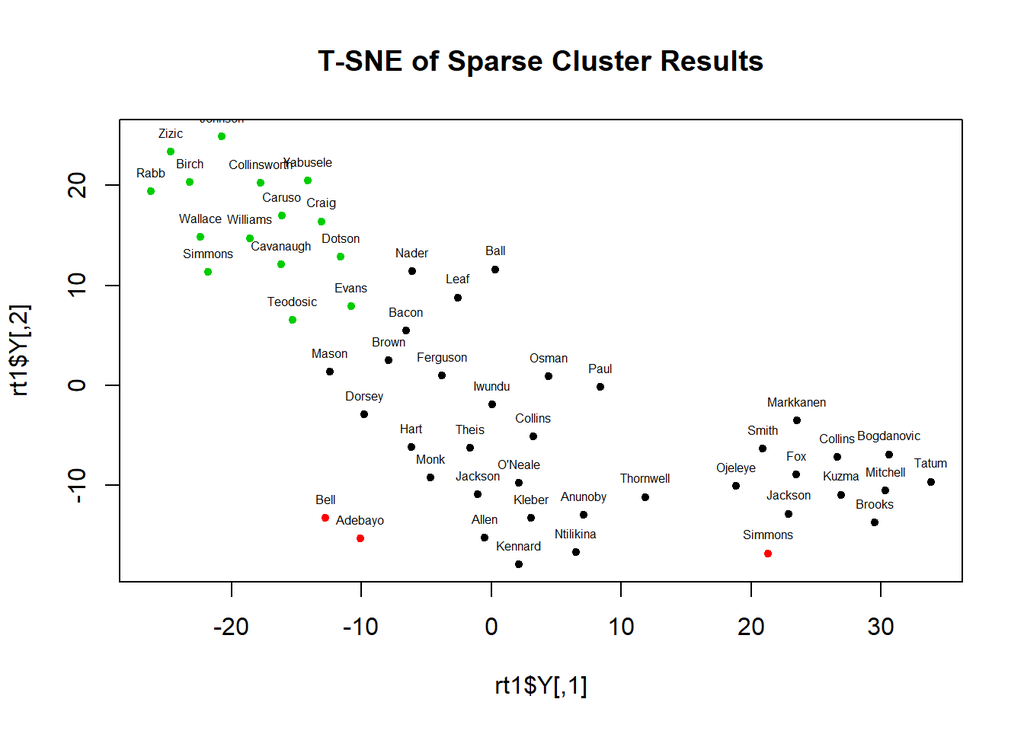

```r
#for data visualization (not necessarily helpful but nice way to aggregate players)
library(Rtsne); par(mfrow = c(1,1))
set.seed(922019)
rt1 <- Rtsne(nba_clust$u, perp = 10, is_distance = TRUE)
plot(rt1$Y, pch = 20, col = factor(groups))
title("T-SNE of Sparse Cluster Results")
text(rt1$Y, pch = 20, label = nba$LAST, cex = 0.5, pos = 3)
```

Now I try a couple different tuning parameter values and compare the results. For the strong lasso penalty I used a wbound of 1.1 (the minimum w value is 1), for moderate I used 2, and for weak I used 10.

```r
#wbound is limited by being GREATER than 1
nba_clust2 <- nba_mat %>% HierarchicalSparseCluster(., wbound = 1.1)
```

```
## 12
```

```r
nba_clust3 <- nba_mat %>% HierarchicalSparseCluster(., wbound = 2)
```

```
## 123456
```

```r
nba_clust4 <- nba_mat %>% HierarchicalSparseCluster(., wbound = 10)
```

```
## 1234567
```

The below plots compare several different levels of the tuning parameter. Sparse clustering was used on the data to develop clusters, and then the U matrix that was generated from each version was input into t-SNE. The t-SNE results on the sparse distance matrices was then compared to the solution.

The colors are based on a 3-cluster solution. The value of 3 was chosen arbitrarily, but such a choice could be optimized in later work.

```r
#show the weight vectors
nba_clust2$ws #strong lasso
```

```
##            [,1]
##  [1,] 0.9944099
##  [2,] 0.1055883
##  [3,] 0.0000000
##  [4,] 0.0000000
##  [5,] 0.0000000
##  [6,] 0.0000000
##  [7,] 0.0000000
##  [8,] 0.0000000
##  [9,] 0.0000000
## [10,] 0.0000000
## [11,] 0.0000000
## [12,] 0.0000000
## [13,] 0.0000000
## [14,] 0.0000000
## [15,] 0.0000000
## [16,] 0.0000000
## [17,] 0.0000000
## [18,] 0.0000000
## [19,] 0.0000000
## [20,] 0.0000000
```

```r
nba_clust3$ws
```

```
##            [,1]
##  [1,] 0.7280857
##  [2,] 0.5603461
##  [3,] 0.2414428
##  [4,] 0.0000000
##  [5,] 0.0000000
##  [6,] 0.0551136
##  [7,] 0.0000000
##  [8,] 0.0000000
##  [9,] 0.2725045
## [10,] 0.0000000
## [11,] 0.0000000
## [12,] 0.1425227
## [13,] 0.0000000
## [14,] 0.0000000
## [15,] 0.0000000
## [16,] 0.0000000
## [17,] 0.0000000
## [18,] 0.0000000
## [19,] 0.0000000
## [20,] 0.0000000
```

```r
nba_clust4$ws #weak penalty
```

```
##               [,1]
##  [1,] 0.6990559640
##  [2,] 0.5488478610
##  [3,] 0.2722468249
##  [4,] 0.0045624251
##  [5,] 0.0226168326
##  [6,] 0.1003335219
##  [7,] 0.0005955296
##  [8,] 0.0044937073
##  [9,] 0.3017152789
## [10,] 0.0008188785
## [11,] 0.0016062717
## [12,] 0.1818695104
## [13,] 0.0003722502
## [14,] 0.0028937401
## [15,] 0.0046284915
## [16,] 0.0042656302
## [17,] 0.0002167173
## [18,] 0.0001022502
## [19,] 0.0008924980
## [20,] 0.0344657306
```

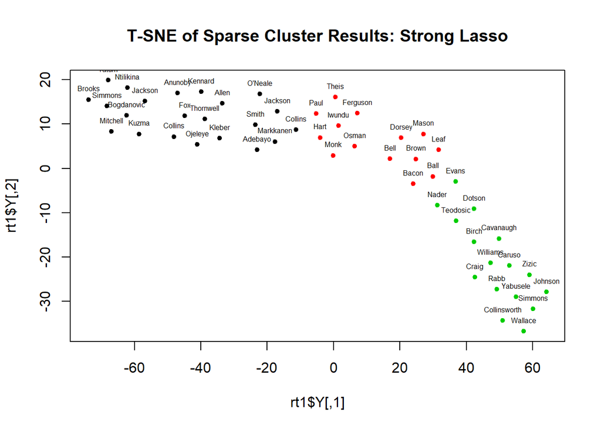

```r
#do the clusters differ?
groups1 <- cutree(nba_clust2$hc, k = 3)
groups2 <- cutree(nba_clust3$hc, k = 3)
groups3 <- cutree(nba_clust4$hc, k = 3)

#Strong Lasso
rt1 <- Rtsne(nba_clust2$u,perplexity = 10, is_distance = TRUE)
plot(rt1$Y, pch = 20, col = factor(groups1))
title("T-SNE of Sparse Cluster Results: Strong Lasso")
text(rt1$Y, pch = 20, label = nba$LAST, cex = 0.5, pos = 3)
```

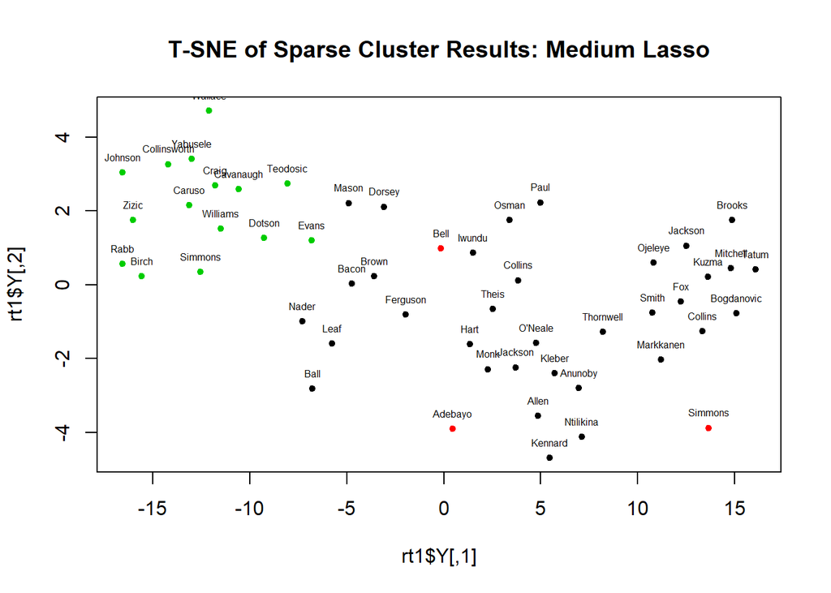

```r
#Middle Lasso
rt1 <- Rtsne(nba_clust3$u, perplexity = 10, is_distance = TRUE)
plot(rt1$Y, pch = 20, col = factor(groups2))
title("T-SNE of Sparse Cluster Results: Medium Lasso")
text(rt1$Y, pch = 20, label = nba$LAST, cex = 0.5, pos = 3)
```

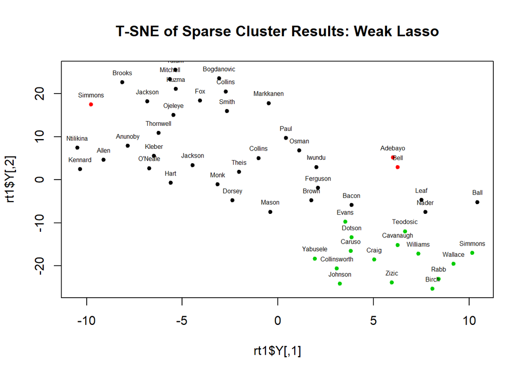

```r
#Weak Lasso
rt1 <- Rtsne(nba_clust4$u, perplexity = 10, is_distance = TRUE)
plot(rt1$Y, pch = 20, col = factor(groups3))
title("T-SNE of Sparse Cluster Results: Weak Lasso")
text(rt1$Y, pch = 20, label = nba$LAST, cex = 0.5, pos = 3)
```

A function that does this is given below:

It seems that this runs reasonably well on small datasets but breaks on large ones. This has to do with the functionality of the sparcl call - it cannnot handle datasets in the neighborhood of 10,000 records or larger.

```r
##Prior to using:
# make sure all non-numeric variables are treated as numeric factors, or remove
# remove all missing observations or impute


sparseTSNE <- function(data, perplexity = 10, lambda = 5, nclust = 3, title = "Sparse t-SNE plot"){
  #data is a data frame, perplexity is used for t-SNE, and lambda is the tuning parameter (>1) for lasso
  #checks to make sure the right packages are loaded
  library(Rtsne)
  library(sparcl)
  #calculates the spares clustering of the data
  temp_mat <- data %>% na.omit() %>% as.matrix() #needs to remove NA and non-numeric data
  clust <- HierarchicalSparseCluster(temp_mat, wbound = lambda)

  #use tsne on the DISTANCE MATRIX so make sure is_distance = TRUE
  tsne1 <- Rtsne(clust$u, perplexity = perplexity, is_distance = TRUE)

  #generate the plot
  ##specify grps for colors
  grps <- cutree(clust$hc, k = nclust)
  df <- as.data.frame(tsne1$Y)
  names(df) <- c("X1","X2")
  p <- ggplot(df, aes(X1,X2)) + geom_point(color = factor(grps)) + ggtitle("Sparse TSNE") + theme_bw()

return(list(plot = p, cluster_ob = clust))}
```

Testing the function:

```r
#test on a couple datasets
qb_select <- qb %>% dplyr::select(-c(qb,lg,home_away))
#can't run this because it throws an error
#sparseTSNE(qb_select) #this produces an error because the dataset is 'large'

#on a smaller size
temp <- dplyr::distinct(qb_select[1:5000,])
sparseTSNE(temp)
```

```
## 123
```

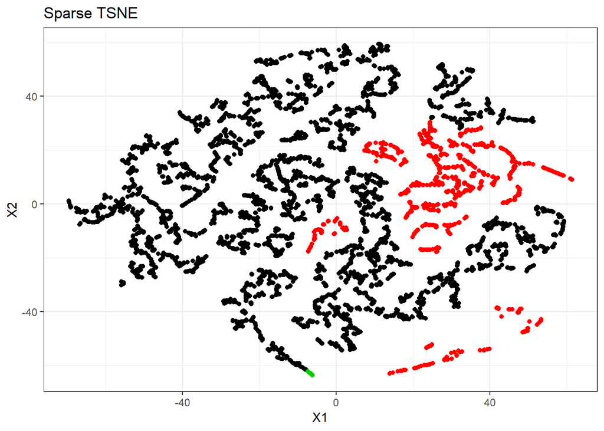

```
##
## $cluster_ob
## Wbound is  5 :
## Number of non-zero weights:  11
## Sum of weights:  1.083531
```

## Optimizing the tuning parameter:

The attached vignette includes some code on how to use the HierarchicalSparseCluster.permute function to pick the ‘best’ tuning parameter value. Revisiting the NBA data, we can assess the different values of the tuning parameter:

When interpreting the plot below, the x axis refers to the **number of nonzero weights** not the value of the tuning parameter itself. I add that as text.

```r
 # Do tuning parameter selection for sparse hierarchical clustering
 # Just need to specify a grid for it to search
  perm.out <- HierarchicalSparseCluster.permute(nba_mat, wbounds=c(1.1,seq(1.5,10, by = .5)),
nperms=5)
```

```
## Running sparse hierarchical clustering on unpermuted data
## 12345678910111213141516171819
## Running sparse hierarchical clustering on permuted data
## Permutation  1  of  5
## 12345678910111213141516171819
## Permutation  2  of  5
## 12345678910111213141516171819
## Permutation  3  of  5
## 12345678910111213141516171819
## Permutation  4  of  5
## 12345678910111213141516171819
## Permutation  5  of  5
## 12345678910111213141516171819
```

```r
  print(perm.out)
```

```
## Tuning parameter selection results for Sparse Hierarchical Clustering:
##    Wbound # Non-Zero W's Gap Statistic Standard Deviation
## 1     1.1              2        0.0431             0.0010
## 2     1.5              4        0.1318             0.0026
## 3     2.0              6        0.1209             0.0029
## 4     2.5             20        0.1164             0.0029
## 5     3.0             20        0.1164             0.0029
## 6     3.5             20        0.1164             0.0029
## 7     4.0             20        0.1164             0.0029
## 8     4.5             20        0.1164             0.0029
## 9     5.0             20        0.1164             0.0029
## 10    5.5             20        0.1164             0.0029
## 11    6.0             20        0.1164             0.0029
## 12    6.5             20        0.1164             0.0029
## 13    7.0             20        0.1164             0.0029
## 14    7.5             20        0.1164             0.0029
## 15    8.0             20        0.1164             0.0029
## 16    8.5             20        0.1164             0.0029
## 17    9.0             20        0.1164             0.0029
## 18    9.5             20        0.1164             0.0029
## 19   10.0             20        0.1164             0.0029
## Tuning parameter that leads to largest Gap statistic:  1.5
```

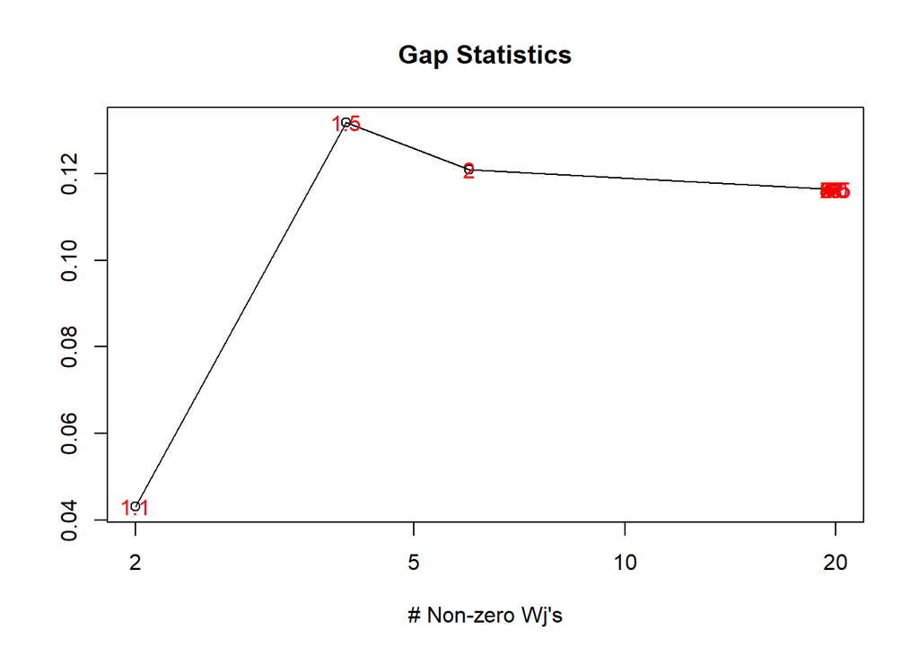

```r
  plot(perm.out)
  text(perm.out$nnonzerows, perm.out$gaps, labels = perm.out$wbounds, col = "red")
```

From the Github page, the code for HierarchicalSparseCluster.permute is included in the code chunk below. The function appears to take default values of 10 permtations and requires a sequence of tuning parameters to consider (with minimum value 1). Dissimilarity is computed as squared Euclidean distance but absolute value can be used as well.

```r
'HierarchicalSparseCluster.permute` <-
function(x,  nperms=10, wbounds=NULL, dissimilarity=c("squared.distance","absolute.value"), standardize.arrays=FALSE){
  dissimilarity <- match.arg(dissimilarity)
  if(is.null(wbounds)) wbounds <- seq(1.1, sqrt(ncol(x))*.7, len=10)
  if(min(wbounds)<=1) stop("Cannot have wbounds <= 1")
  if(length(wbounds)<2) stop("Wbounds should be a vector with at least 2 elements.")
  tots <- rep(NA,length(wbounds))
  permtots <- matrix(NA, nrow=length(wbounds), ncol=nperms)
  nnonzerows <- rep(NA,length(wbounds))
  if(standardize.arrays){
    #x <- t(scale(t(x),T,T))
    x <- sweep(x,1,apply(x,1,mean,na.rm=TRUE),"-")
    x <- sweep(x,1,apply(x,1,sd,na.rm=TRUE),"/")
  }
  cat("Running sparse hierarchical clustering on unpermuted data",fill=TRUE)
  for(i in 1:length(wbounds)){
    cat(i,fill=FALSE)
    if(i==1) out <- HierarchicalSparseCluster(x,  wbound=wbounds[i],silent=TRUE,dissimilarity=dissimilarity)
    if(i>1) out <- HierarchicalSparseCluster(x=NULL,dists=out$dists,wbound=wbounds[i], silent=TRUE,dissimilarity=dissimilarity)
    nnonzerows[i] <- sum(out$ws!=0)
    tots[i] <- out$crit
  }
  cat(fill=TRUE)
  cat("Running sparse hierarchical clustering on permuted data",fill=TRUE)
  permdists <- out$dists
  for(k in 1:nperms){
    cat("Permutation ", k, " of ", nperms,fill=TRUE)
    # Oooohhhh.. It turns out that rather than permuting the columns of x and then computing a dist matrix, we can simply permute
    #  the columns of the (n choose 2)xp dist matrix.
    for(j in 1:ncol(permdists)) permdists[,j] <- sample(permdists[,j])
    for(i in 1:length(wbounds)){
      cat(i,fill=FALSE)
      perm.out <- HierarchicalSparseCluster(x=NULL, dists=permdists,wbound=wbounds[i], silent=TRUE,dissimilarity=dissimilarity)
      permtots[i,k] <- max(perm.out$crit)
    }
    cat(fill=TRUE)
  }
  gaps <- (log(tots)-apply(log(permtots),1,mean))
  out <- list(tots=tots, permtots=permtots, nnonzerows=nnonzerows, gaps=gaps, sdgaps=apply(log(permtots),1,sd), wbounds=wbounds, bestw=wbounds[which.max(gaps)], dists=out$dists)
  class(out) <- "HierarchicalSparseCluster.permute"
  cat(fill=TRUE)
  return(out)
}

print.HierarchicalSparseCluster.permute <- function(x,...){
  cat("Tuning parameter selection results for Sparse Hierarchical Clustering:", fill=TRUE)
  mat <- round(cbind(x$wbounds, x$nnonzerows, x$gaps, x$sdgaps),4)
  dimnames(mat) <- list(1:length(x$wbounds), c("Wbound", "# Non-Zero Ws", "Gap Statistic", "Standard Deviation"))
  print(mat, quote=FALSE)
  cat("Tuning parameter that leads to largest Gap statistic: ", x$bestw, fill=TRUE)
}

plot.HierarchicalSparseCluster.permute <- function(x,...){
  plot(x$nnonzerows, x$gaps, log="x", main="Gap Statistics", xlab="# Non-zero Wjs", ylab="")
  lines(x$nnonzerows, x$gaps)
}
```

## Additional Choices we may need to consider

The method used to calculate dissimilarity is something we can change in this code.